# Final Project

Trump Tower Tappers

2017/4/8

# Table of contents

0. Approach
1. Data cleaning & preparation 1.1 Step logit 1.2 Random forest on variables ID’d by step logit
2. Run ML models with bagged data
3. Generate predictions for all models
4. Calculate accuracy and kappa
5. Generate ensemble
6. Summary

# 0. Approach

Our approach to this dataset follows a simple sequence. First, we normalize, clean, prep, and otherwise munge the data so it is fit for analysis. Next, we conduct a stepwise logistic regression to identify significant prediction variables. The variables identified in that step are then applied to a random forest model to confirm the significance. Several machine learning models are then generated and used to create predictions to compare to a test data set. These predictions are then combined via classification tree to provide a stacked ensemble model.

# 1. Data cleaning & preparation

# Import library

```r
rm(list = ls())

suppressPackageStartupMessages(library(multcomp))
suppressPackageStartupMessages(library(party))
suppressPackageStartupMessages(library(plyr))
suppressPackageStartupMessages(library(dplyr))
suppressPackageStartupMessages(library(class))
suppressPackageStartupMessages(library(gmodels))
suppressPackageStartupMessages(library(stats))
suppressPackageStartupMessages(library(magrittr))
suppressPackageStartupMessages(library(beepr))
suppressPackageStartupMessages(library(caret))
suppressPackageStartupMessages(library(kernlab))
suppressPackageStartupMessages(library(neuralnet))
suppressPackageStartupMessages(library(randomForest))
suppressPackageStartupMessages(library(ada))
suppressPackageStartupMessages(library(C50))
suppressPackageStartupMessages(library(vcd))
```

# Create new variables to show gaps between objects and partners

```r
normalize<-function(x){
  return((x-min(x))/(max(x)-min(x)))}

#age difference
# sdclean$age_dif<-sdclean$age - sdclean$age_o

# #intelligence difference between sat score and partner's preference
# x<-data.frame(lapply(sdclean[18], normalize))
# sdclean$mn_sat<-as.numeric(sdclean$mn_sat)
# y<-as.data.frame(lapply(sdclean[69], normalize))
# z<- x-y

#partner's preference and actual rating
sdclean$att_dif<-sdclean$pf_o_att - sdclean$attr1_1
sdclean$sinc_dif<-sdclean$pf_o_sin - sdclean$sinc1_1
sdclean$intel_dif<-sdclean$pf_o_int - sdclean$intel1_1
sdclean$fun_dif<-sdclean$pf_o_fun - sdclean$fun1_1
sdclean$amb_dif<-sdclean$pf_o_amb - sdclean$amb1_1
sdclean$shar_dif<-sdclean$pf_o_sha - sdclean$shar1_1
```

# Normalize variables

```r
#age difference
# a<-data.frame(lapply(sdclean[69], normalize))
# sdclean$age_dif_norm<-a$age_dif

#intelligence difference
# b<-as.data.frame(lapply(z[1], normalize))
# sdclean$intel_dif<-b$intel_o

#date frequency
# sdclean$date<-as.numeric(sdclean$date)
# c<-data.frame(lapply(sdclean[31], normalize))
# sdclean$date_norm<-c$date

#partner's preference and actual rating
d<-data.frame(lapply(sdclean[69], normalize))
sdclean$att_dif_norm<-d$att_dif

e<-data.frame(lapply(sdclean[70], normalize))
sdclean$sinc_dif_norm<-e$sinc_dif

f<-data.frame(lapply(sdclean[71], normalize))
sdclean$intel_dif_norm<-f$intel_dif

g<-data.frame(lapply(sdclean[72], normalize))
sdclean$fun_dif_norm<-g$fun_dif

h<-data.frame(lapply(sdclean[73], normalize))
sdclean$amb_dif_norm<-h$amb_dif

i<-data.frame(lapply(sdclean[74], normalize))
sdclean$shar_dif_norm<-i$shar_dif

#rating of partners by objects (inter-correlation)
# j<-data.frame(lapply(sdclean[5], normalize))
# sdclean$int_corr_norm<-j$int_corr

sdclean2 <- as.data.frame(model.matrix(~ ., sdclean))

sdclean2$`(Intercept)` <- NULL

sdclean2$field_cdSocSciePsych <- sdclean2$`field_cdSocScie/Psych`
sdclean2$go_out2Week <- sdclean2$`go_out2/Week`
sdclean2$go_out1Week <- sdclean2$`go_out1/Week`
sdclean2$go_out2Month <- sdclean2$`go_out2/Month`
sdclean2$go_out1Month <- sdclean2$`go_out1/Month`
sdclean2$go_outSVRLYear <- sdclean2$`go_outSVRL/Year`
sdclean2$career_cAcademicResearch <- sdclean2$`career_cAcademic/Research`
sdclean2$career_cBankingConsulting <- sdclean2$`career_cBanking/Consulting`

sdclean2$`field_cdSocScie/Psych` <- NULL
sdclean2$`go_out2/Week` <- NULL
sdclean2$`go_out1/Week` <- NULL
sdclean2$`go_out2/Month` <- NULL
sdclean2$`go_out1/Month` <- NULL
sdclean2$`go_outSVRL/Year` <- NULL
sdclean2$`career_cAcademic/Research` <- NULL
sdclean2$`career_cBanking/Consulting` <- NULL
save(sdclean2, file = "sdclean2")

#Working with sdclean data, not sdfinal
##Make train and test data

load(file = "sdclean2")

set.seed(628)
train_data_sdclean<-sdclean2[1:4500,]
test_data_sdclean<-sdclean2[4501:6499,]

#Make labels for train and test data
train_label_sdclean<-sdclean2$match1[1:4500]
test_label_sdclean<-sdclean2$match1[4501:6499]

train_data_sdclean_noResp <- train_data_sdclean
test_data_sdclean_noResp <- test_data_sdclean

train_data_sdclean_noResp$match1 <- NULL
test_data_sdclean_noResp$match1 <- NULL

###create bagged train data
# table(train_data_sdclean$match1)
# count(match1 == 1) = 764
train_data_bag_0 <- sample_n(train_data_sdclean, 800, replace = FALSE) %>% filter(match1 == 0)

train_data_bag_1 <- train_data_sdclean %>% filter(match1 == 1)
train_data_bag <- bind_rows(train_data_bag_0,train_data_bag_1)
#randomize dataset
train_data_bag <- train_data_bag[sample(nrow(train_data_bag)),]

train_label_bag <- train_data_bag$match1
train_data_bag_noResp <- train_data_bag
train_data_bag_noResp$match1 <- NULL
```

# 1.1 Step Logit to identify significant prediction variables

```r
log_step_f <- colnames(sdclean2) %>%
    {paste(.[! . %in% "match1"], collapse = " + ")} %>%
    paste("match1 ~ ", .) %>%
    as.formula()

log_model_step <- glm(train_label_sdclean ~ 1, data = train_data_sdclean, family = binomial)
#log_model_step <- step(log_model_step, scope = (log_step_f), direction = "forward")


#save(log_model_step,file = "log_model_step")
load(file = "log_model_step")
summary(log_model_step)
```

```
##
## Call:
## glm(formula = train_label_sdclean ~ dec_o + prob_o + pf_o_sha +
##     gender1 + race2 + pf_o_sin + attr1_1 + exphappy + met_o +
##     sports + race_o4 + career_cPolitics + career_cUndecided +
##     yoga + field_cdBusiness + field_cdUndergrad + gaming + dining +
##     art + race_o3 + movies + go_out1Month + career_cPsychologist +
##     race3 + clubbing + goalToSayIDidIt + amb1_1 + goalSRSRelationship +
##     fun_o + attr_o + intel2_1 + career_cBankingConsulting + int_corr +
##     sinc_o + pf_o_fun + age + go_out2Month + field_cdFineArts,
##     family = binomial, data = train_data_sdclean)
##
## Deviance Residuals:
##      Min        1Q    Median        3Q       Max
## -2.19282  -0.42787  -0.00004  -0.00002   2.54732
##
## Coefficients:
##                             Estimate Std. Error z value Pr(>|z|)
## (Intercept)               -1.903e+01  3.276e+02  -0.058 0.953681
## dec_o                      2.051e+01  3.276e+02   0.063 0.950081
## prob_o                     1.635e-01  2.956e-02   5.530 3.21e-08 ***
## pf_o_sha                  -3.607e-02  8.479e-03  -4.254 2.10e-05 ***
## gender1                    6.762e-01  1.414e-01   4.781 1.74e-06 ***
## race2                     -5.548e-01  1.196e-01  -4.640 3.48e-06 ***
## pf_o_sin                  -2.786e-02  7.809e-03  -3.568 0.000360 ***
## attr1_1                   -1.846e-02  5.261e-03  -3.510 0.000449 ***
## exphappy                   1.456e-01  3.306e-02   4.403 1.07e-05 ***
## met_o                     -7.126e-01  2.038e-01  -3.497 0.000471 ***
## sports                    -7.672e-02  2.240e-02  -3.425 0.000615 ***
## race_o4                   -3.886e-01  1.287e-01  -3.018 0.002541 **
## career_cPolitics          -2.303e+00  8.205e-01  -2.807 0.004999 **
## career_cUndecided         -6.413e-01  2.756e-01  -2.327 0.019942 *
## yoga                       4.720e-02  2.038e-02   2.316 0.020584 *
## field_cdBusiness          -4.523e-01  1.702e-01  -2.658 0.007862 **
## field_cdUndergrad         -1.966e+01  4.375e+03  -0.004 0.996415
## gaming                     5.809e-02  2.227e-02   2.608 0.009108 **
## dining                    -1.028e-01  3.553e-02  -2.892 0.003826 **
## art                        8.659e-02  2.804e-02   3.088 0.002015 **
## race_o3                    4.615e-01  2.072e-01   2.227 0.025937 *
## movies                    -8.829e-02  3.272e-02  -2.698 0.006972 **
```

[output cut: 12 more lines]

```
## sinc_o                     6.131e-02  4.030e-02   1.521 0.128194
## pf_o_fun                   1.318e-02  8.738e-03   1.508 0.131515
## age                       -2.862e-02  1.709e-02  -1.674 0.094104 .
## go_out2Month               4.935e-01  2.731e-01   1.807 0.070752 .
## field_cdFineArts          -5.804e-01  3.965e-01  -1.464 0.143255
## ---
## Signif. codes:  0 '***' 0.001 '**' 0.01 '*' 0.05 '.' 0.1 ' ' 1
##
## (Dispersion parameter for binomial family taken to be 1)
##
##     Null deviance: 4099.8  on 4499  degrees of freedom
## Residual deviance: 2263.9  on 4461  degrees of freedom
## AIC: 2341.9
##
## Number of Fisher Scoring iterations: 19
```

```r
sig_var <- c("prob_o","pf_o_sha","gender1","race2","pf_o_sin","attr1_1","exphappy","met_o","sports","race_o4","career_cPolitics","career_cUndecided","yoga","field_cdBusiness","gaming","dining","art","movies","attr_o","race_o3","go_out1Month","career_cPsychologist","clubbing","goalToSayIDidIt","amb1_1","goalSRSRelationship","fun_o","career_cBankingConsulting")
```

# 1.2 Random forest on significant variables

```r
#create the formula for random forest "match ~ blah + blah + blah..."
sig_var_f <- sig_var %>%
    {paste(.[! . %in% "match1"], collapse = " + ")} %>%
    paste("match1 ~ ", .) %>%
    as.formula()

sig_var_f
```

```
## match1 ~ prob_o + pf_o_sha + gender1 + race2 + pf_o_sin + attr1_1 +
##     exphappy + met_o + sports + race_o4 + career_cPolitics +
##     career_cUndecided + yoga + field_cdBusiness + gaming + dining +
##     art + movies + attr_o + race_o3 + go_out1Month + career_cPsychologist +
##     clubbing + goalToSayIDidIt + amb1_1 + goalSRSRelationship +
##     fun_o + career_cBankingConsulting
## <environment: 0x7f9cb6f67b18>
```

```r
#run the RANdom FORest on the SIGnificant VARiables
set.seed(628)
ranfor_alldata <- randomForest(formula = sig_var_f, data = train_data_sdclean, importance=TRUE)
ranfor_bag <- randomForest(formula = sig_var_f, data = train_data_bag, importance=TRUE)
```

# 1.2.1 - Comparing random forest with all data -vs- bagged data

We first evaluated a random forest model using the significant variables and full cleaned dataset. However, the random forest model provided results that were not statistically different than the No Information Rate. Given that, we then “bagged” the training data, keeping all positive Match results and randomly sampling out the negative Match results until the total of positive and negative results were roughly equal. This was done in hopes that the models would provide better predict positive results.

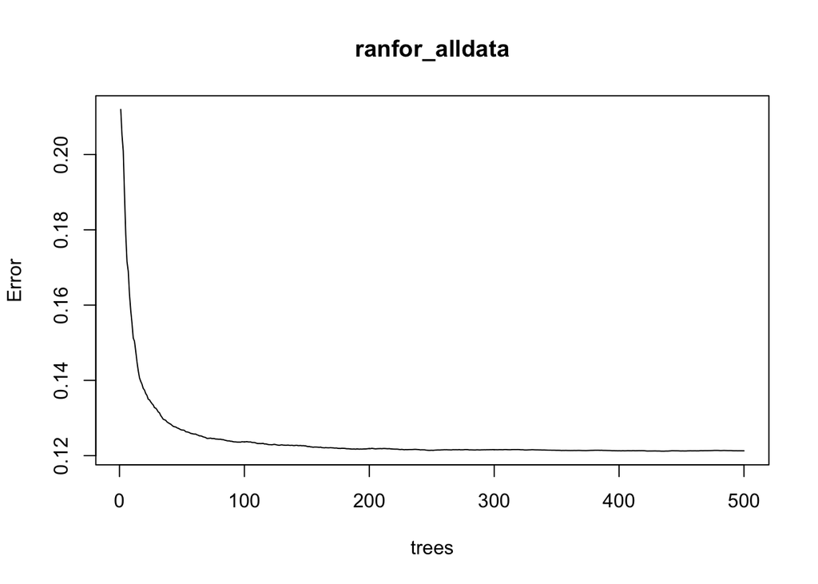

```r
#All Data error plot
plot(ranfor_alldata)
```

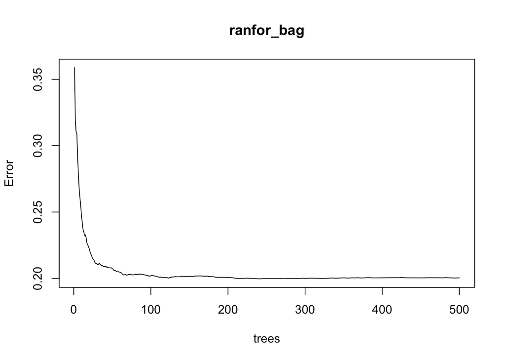

```r
#Bagged data error plot
plot(ranfor_bag)
```

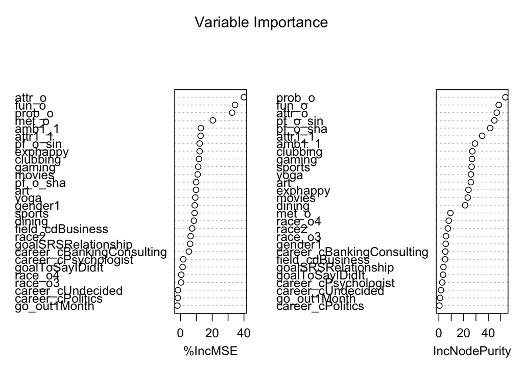

```r
#All Data variable importance
varImpPlot(ranfor_alldata,
           sort = T,
           main="Variable Importance")
```

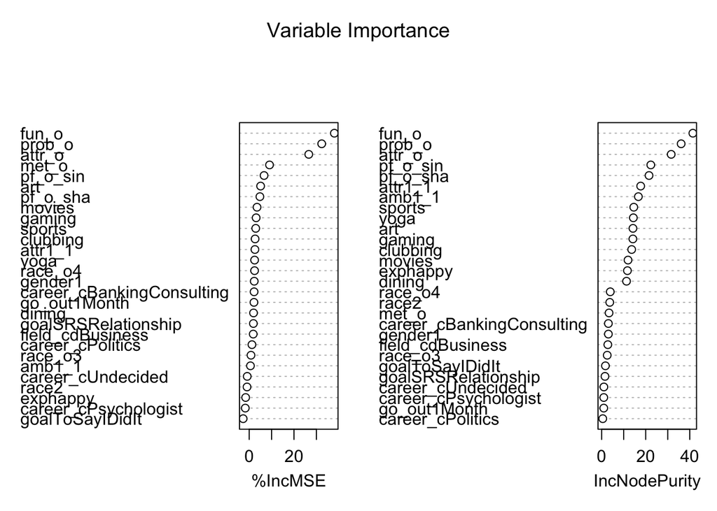

```r
#Bagged data variable importance
varImpPlot(ranfor_bag,
           sort = T,
           main="Variable Importance")
```

```r
#Run prediction of random forest model using significant predictor variables and full data set
ranfor_alldata_pred <- predict(ranfor_alldata,test_data_sdclean) %>% {ifelse(. > 0.5, "1", "0")}
confusionMatrix(data=ranfor_alldata_pred,reference=test_label_sdclean)
```

```
## Confusion Matrix and Statistics
##
##           Reference
## Prediction    0    1
##          0 1618  294
##          1   37   50
##
##                Accuracy : 0.8344
##                  95% CI : (0.8174, 0.8505)
##     No Information Rate : 0.8279
##     P-Value [Acc > NIR] : 0.2303
##
##                   Kappa : 0.1747
##  Mcnemar's Test P-Value : <2e-16
##
##             Sensitivity : 0.9776
##             Specificity : 0.1453
##          Pos Pred Value : 0.8462
##          Neg Pred Value : 0.5747
##              Prevalence : 0.8279
##          Detection Rate : 0.8094
##    Detection Prevalence : 0.9565
##       Balanced Accuracy : 0.5615
##
##        'Positive' Class : 0
##
```

```r
#Run prediction of random forest model using significant predictor variables and bagged data set
ranfor_bag_pred <- predict(ranfor_bag,test_data_sdclean) %>% {ifelse(. > 0.5, "1", "0")}
confusionMatrix(data=ranfor_bag_pred,reference=test_label_sdclean)
```

```
## Confusion Matrix and Statistics
##
##           Reference
## Prediction    0    1
##          0 1031   87
##          1  624  257
##
##                Accuracy : 0.6443
##                  95% CI : (0.6229, 0.6653)
##     No Information Rate : 0.8279
##     P-Value [Acc > NIR] : 1
##
##                   Kappa : 0.2287
##  Mcnemar's Test P-Value : <2e-16
##
##             Sensitivity : 0.6230
##             Specificity : 0.7471
##          Pos Pred Value : 0.9222
##          Neg Pred Value : 0.2917
##              Prevalence : 0.8279
##          Detection Rate : 0.5158
##    Detection Prevalence : 0.5593
##       Balanced Accuracy : 0.6850
##
##        'Positive' Class : 0
##
```

# 2. Create models with bagged data

```r
#Log model
set.seed(628)
log_model <- glm(formula = sig_var_f, data = train_data_bag, family = binomial)

#Develop KNN Models
set.seed(628)
knn_pred_21<-knn(train=train_data_bag_noResp, test=test_data_sdclean_noResp, cl=train_label_bag, k=21)
set.seed(628)
knn_pred_7<-knn(train=train_data_bag_noResp, test=test_data_sdclean_noResp, cl=train_label_bag, k=7)

#develop SVM models
set.seed(628)
library(e1071)
svm_model_lin <- svm(formula = sig_var_f, data = train_data_bag, kernel = "linear")

set.seed(628)
svm_model_rad <- svm(formula = sig_var_f, data = train_data_bag, kernel = "radial")

#develop random forest model
set.seed(628)
random_forest_model <- randomForest(formula = sig_var_f, data = train_data_bag)
#develop ctree model
set.seed(628)
library(partykit)
ctree_model <- ctree(formula = sig_var_f, data = train_data_bag, control = ctree_control(mincriterion = .90))

#develop boosted tree
#C5.0 needs response as a factor
train_data_bag$match1 <- as.factor(train_data_bag$match1)
boosted_tree_model <- C5.0(formula = sig_var_f, data = train_data_bag, trials = 100)
train_data_bag$match1 <- as.numeric(train_data_bag$match1) -1

#develop ANN model - NOPE!  Always blew up.
#library(neuralnet)
#set.seed(628)
#ANN_model <- neuralnet(formula = sig_var_f, data = train_data_sdclean, lifesign = "full", hidden = 20)
```

# 3. Make Predictions from Test Data

# 3.1 Logistic Prediction

```r
log_pred <- predict(log_model, test_data_sdclean, type = "response") %>% {ifelse(. > 0.5, "1", "0")} %>% as.numeric()
confusionMatrix(data=log_pred,reference=test_label_sdclean)
```

```
## Confusion Matrix and Statistics
##
##           Reference
## Prediction    0    1
##          0 1064   97
##          1  591  247
##
##                Accuracy : 0.6558
##                  95% CI : (0.6345, 0.6767)
##     No Information Rate : 0.8279
##     P-Value [Acc > NIR] : 1
##
##                   Kappa : 0.2301
##  Mcnemar's Test P-Value : <2e-16
##
##             Sensitivity : 0.6429
##             Specificity : 0.7180
##          Pos Pred Value : 0.9165
##          Neg Pred Value : 0.2947
##              Prevalence : 0.8279
##          Detection Rate : 0.5323
##    Detection Prevalence : 0.5808
##       Balanced Accuracy : 0.6805
##
##        'Positive' Class : 0
##
```

```r
k_log_pred <- Kappa(table(log_pred, test_label_sdclean))
```

# 3.2 kNN (21) Prediction

```r
k_kNN_21 <- Kappa(table(knn_pred_21, test_label_sdclean))
confusionMatrix(data=knn_pred_21,reference=test_label_sdclean)
```

```
## Confusion Matrix and Statistics
##
##           Reference
## Prediction   0   1
##          0 679  77
##          1 976 267
##
##                Accuracy : 0.4732
##                  95% CI : (0.4512, 0.4954)
##     No Information Rate : 0.8279
##     P-Value [Acc > NIR] : 1
##
##                   Kappa : 0.0916
##  Mcnemar's Test P-Value : <2e-16
##
##             Sensitivity : 0.4103
##             Specificity : 0.7762
##          Pos Pred Value : 0.8981
##          Neg Pred Value : 0.2148
##              Prevalence : 0.8279
##          Detection Rate : 0.3397
##    Detection Prevalence : 0.3782
##       Balanced Accuracy : 0.5932
##
##        'Positive' Class : 0
##
```

# 3.3 kNN (7) Prediction

```r
k_kNN_7 <- Kappa(table(knn_pred_7, test_label_sdclean))
confusionMatrix(data=knn_pred_7,reference=test_label_sdclean)
```

```
## Confusion Matrix and Statistics
##
##           Reference
## Prediction   0   1
##          0 749  88
##          1 906 256
##
##                Accuracy : 0.5028
##                  95% CI : (0.4806, 0.5249)
##     No Information Rate : 0.8279
##     P-Value [Acc > NIR] : 1
##
##                   Kappa : 0.1013
##  Mcnemar's Test P-Value : <2e-16
##
##             Sensitivity : 0.4526
##             Specificity : 0.7442
##          Pos Pred Value : 0.8949
##          Neg Pred Value : 0.2203
##              Prevalence : 0.8279
##          Detection Rate : 0.3747
##    Detection Prevalence : 0.4187
##       Balanced Accuracy : 0.5984
##
##        'Positive' Class : 0
##
```

# 3.4 SVM (cartesian) Prediction

```r
svm_pred_lin <- predict(svm_model_lin, test_data_sdclean) %>% {ifelse(. > 0.5, "1", "0")} %>% as.numeric()
k_SVM_lin <- Kappa(table(svm_pred_lin, test_label_sdclean))
confusionMatrix(data=svm_pred_lin,reference=test_label_sdclean)
```

```
## Confusion Matrix and Statistics
##
##           Reference
## Prediction   0   1
##          0 925  82
##          1 730 262
##
##                Accuracy : 0.5938
##                  95% CI : (0.5719, 0.6154)
##     No Information Rate : 0.8279
##     P-Value [Acc > NIR] : 1
##
##                   Kappa : 0.1836
##  Mcnemar's Test P-Value : <2e-16
##
##             Sensitivity : 0.5589
##             Specificity : 0.7616
##          Pos Pred Value : 0.9186
##          Neg Pred Value : 0.2641
##              Prevalence : 0.8279
##          Detection Rate : 0.4627
##    Detection Prevalence : 0.5038
##       Balanced Accuracy : 0.6603
##
##        'Positive' Class : 0
##
```

# 3.5 SVM (polar) Prediction

```r
svm_pred_rad <- predict(svm_model_rad, test_data_sdclean) %>% {ifelse(. > 0.5, "1", "0")} %>% as.numeric()
k_SVM_rad <- Kappa(table(svm_pred_rad, test_label_sdclean))
confusionMatrix(data=svm_pred_rad,reference=test_label_sdclean)
```

```
## Confusion Matrix and Statistics
##
##           Reference
## Prediction   0   1
##          0 982  83
##          1 673 261
##
##                Accuracy : 0.6218
##                  95% CI : (0.6001, 0.6431)
##     No Information Rate : 0.8279
##     P-Value [Acc > NIR] : 1
##
##                   Kappa : 0.2097
##  Mcnemar's Test P-Value : <2e-16
##
##             Sensitivity : 0.5934
##             Specificity : 0.7587
##          Pos Pred Value : 0.9221
##          Neg Pred Value : 0.2794
##              Prevalence : 0.8279
##          Detection Rate : 0.4912
##    Detection Prevalence : 0.5328
##       Balanced Accuracy : 0.6760
##
##        'Positive' Class : 0
##
```

# 3.6 Random Forest Prediction

```r
#re-ran this model just for the sake of order and completeness
ran_for_pred <- predict(random_forest_model, test_data_sdclean) %>% {ifelse(. > 0.5, "1", "0")} %>% as.numeric()
k_ranfor_pred <- Kappa(table(ran_for_pred, test_label_sdclean))
confusionMatrix(data=ran_for_pred,reference=test_label_sdclean)
```

```
## Confusion Matrix and Statistics
##
##           Reference
## Prediction    0    1
##          0 1039   91
##          1  616  253
##
##                Accuracy : 0.6463
##                  95% CI : (0.6249, 0.6673)
##     No Information Rate : 0.8279
##     P-Value [Acc > NIR] : 1
##
##                   Kappa : 0.2264
##  Mcnemar's Test P-Value : <2e-16
##
##             Sensitivity : 0.6278
##             Specificity : 0.7355
##          Pos Pred Value : 0.9195
##          Neg Pred Value : 0.2911
##              Prevalence : 0.8279
##          Detection Rate : 0.5198
##    Detection Prevalence : 0.5653
##       Balanced Accuracy : 0.6816
##
##        'Positive' Class : 0
##
```

# 3.7 Classification Tree Prediction

```r
ctree_pred <- predict(ctree_model, test_data_sdclean) %>% {ifelse(. > 0.5, "1", "0")} %>% as.numeric()
k_ctree_pred <- Kappa(table(ctree_pred, test_label_sdclean))
confusionMatrix(data=ctree_pred,reference=test_label_sdclean)
```

```
## Confusion Matrix and Statistics
##
##           Reference
## Prediction   0   1
##          0 986  96
##          1 669 248
##
##                Accuracy : 0.6173
##                  95% CI : (0.5956, 0.6387)
##     No Information Rate : 0.8279
##     P-Value [Acc > NIR] : 1
##
##                   Kappa : 0.1908
##  Mcnemar's Test P-Value : <2e-16
##
##             Sensitivity : 0.5958
##             Specificity : 0.7209
##          Pos Pred Value : 0.9113
##          Neg Pred Value : 0.2704
##              Prevalence : 0.8279
##          Detection Rate : 0.4932
##    Detection Prevalence : 0.5413
##       Balanced Accuracy : 0.6584
##
##        'Positive' Class : 0
##
```

# 3.8 Boosted Tree Prediction

```r
boosted_tree_pred <- predict(boosted_tree_model, test_data_sdclean)
boosted_tree_pred <- as.numeric(boosted_tree_pred) - 1
k_boosted_pred <- Kappa(table(boosted_tree_pred, test_label_sdclean))
confusionMatrix(data=boosted_tree_pred,reference=test_label_sdclean)
```

```
## Confusion Matrix and Statistics
##
##           Reference
## Prediction    0    1
##          0 1112  109
##          1  543  235
##
##                Accuracy : 0.6738
##                  95% CI : (0.6528, 0.6944)
##     No Information Rate : 0.8279
##     P-Value [Acc > NIR] : 1
##
##                   Kappa : 0.2367
##  Mcnemar's Test P-Value : <2e-16
##
##             Sensitivity : 0.6719
##             Specificity : 0.6831
##          Pos Pred Value : 0.9107
##          Neg Pred Value : 0.3021
##              Prevalence : 0.8279
##          Detection Rate : 0.5563
##    Detection Prevalence : 0.6108
##       Balanced Accuracy : 0.6775
##
##        'Positive' Class : 0
##
```

# 4. Determine accuracy

```r
accuracy <- function(predicted, trueval, model, hideoutput = F) {
  stopifnot(length(predicted) == length(trueval))
  result <- sum(predicted == trueval) / length(predicted)
  if (!hideoutput) {cat("Model:", model, "had", result, "accuracy\n")}
  return(result)
}

a0 = accuracy(log_pred, test_data_sdclean$match1, "Logit", TRUE)
a1 = accuracy(knn_pred_21, test_data_sdclean$match1, "KNN 21", TRUE)
a2 = accuracy(knn_pred_7, test_data_sdclean$match1, "KNN 7", TRUE)
a3 = accuracy(svm_pred_lin, test_data_sdclean$match1, "SVM (cartesian)", TRUE)
a4 = accuracy(svm_pred_rad, test_data_sdclean$match1, "SVM (polar)", TRUE)
a5 = accuracy(ran_for_pred, test_data_sdclean$match1, "Random Forest", TRUE)
a6 = accuracy(ctree_pred, test_data_sdclean$match1, "Ctree", TRUE)
a7 = accuracy(boosted_tree_pred, test_data_sdclean$match1, "Boosted Tree", TRUE)
#a8 = accuracy(ann_pred, test_data_sdclean$match1, "Neural Net 50 (!) Hidden Node", TRUE)

acc_predictions = c(a0,a1,a2,a3,a4,a5,a6,a7)
names = c("Logit", "kNN 21", "kNN 7", "SVM (cartesian)","SVM (polar)","Random Forest","CTree","Boosted Tree")

acc_mat <- data.frame(ModelName = names, accuracy = acc_predictions) %>% print
```

```
##         ModelName  accuracy
## 1           Logit 0.6558279
## 2          kNN 21 0.4732366
## 3           kNN 7 0.5027514
## 4 SVM (cartesian) 0.5937969
## 5     SVM (polar) 0.6218109
## 6   Random Forest 0.6463232
## 7           CTree 0.6173087
## 8    Boosted Tree 0.6738369
```

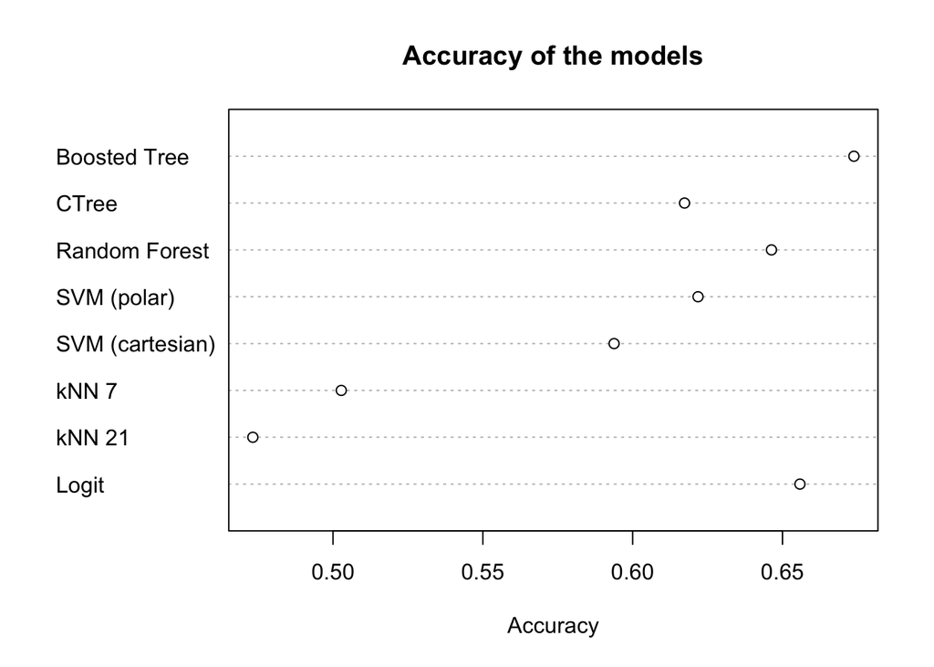

```r
dotchart(acc_predictions, labels = names, main = "Accuracy of the models", xlab = "Accuracy")
```

```r
model_kappas <- c(k_log_pred$Unweighted[1], k_kNN_21$Unweighted[1], k_kNN_7$Unweighted[1], k_SVM_lin$Unweighted[1], k_SVM_rad$Unweighted[1], k_ranfor_pred$Unweighted[1], k_ctree_pred$Unweighted[1], k_boosted_pred$Unweighted[1])

kappa_table <- data.frame(ModelName = names, kappas = model_kappas) %>% print
```

```
##         ModelName     kappas
## 1           Logit 0.23006661
## 2          kNN 21 0.09161028
## 3           kNN 7 0.10132436
## 4 SVM (cartesian) 0.18357604
## 5     SVM (polar) 0.20965416
## 6   Random Forest 0.22640462
## 7           CTree 0.19081373
## 8    Boosted Tree 0.23674320
```

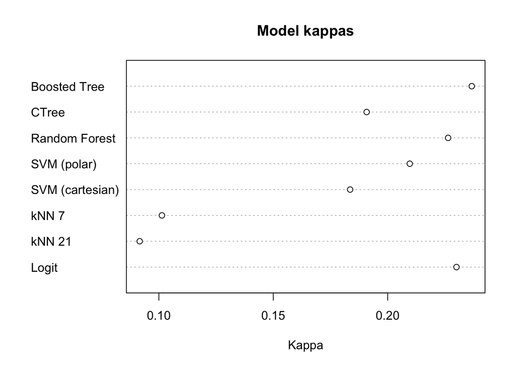

```r
dotchart(model_kappas, labels = names, main = "Model kappas", xlab = "Kappa")
```